# Estimating and checking mixed models

Ben Whalley

Feb 2021

> This worksheet is intended to provide more detail on how to implement mixed models in your own research, introduce techniques for model comparison and paramater testing, and In this session we specify more complex random effects, including examples from experimental data with multiple sources of variation.

# Checking assumptions

As discussed in class, mixed models have many of the same assumptions about residuals as does multiple regression. In particular,

- Residuals should be normally distributed
- Residuals should be similar across the range of fitted values (homoscedasticity)

You can check these assumptions in a few ways. First, let’s refit a model we’ve used before:

```r
pigs <- read_csv('http://bit.ly/psystats-pigs')

m1 <- lmer(weight ~ week + (1|id), data=pigs)
```

We can then extract the residuals from the model using `augment` from the broom package:

```r
m1 %>%
  broom::augment() %>%
  select(.resid) %>%
  head()
```

```
       .resid
1  0.11860656
2  1.90871073
3  2.69881489
4 -0.01108094
5 -0.72097677
6 -0.43087261
```

A good way of checking normality is to simply make a density plot:

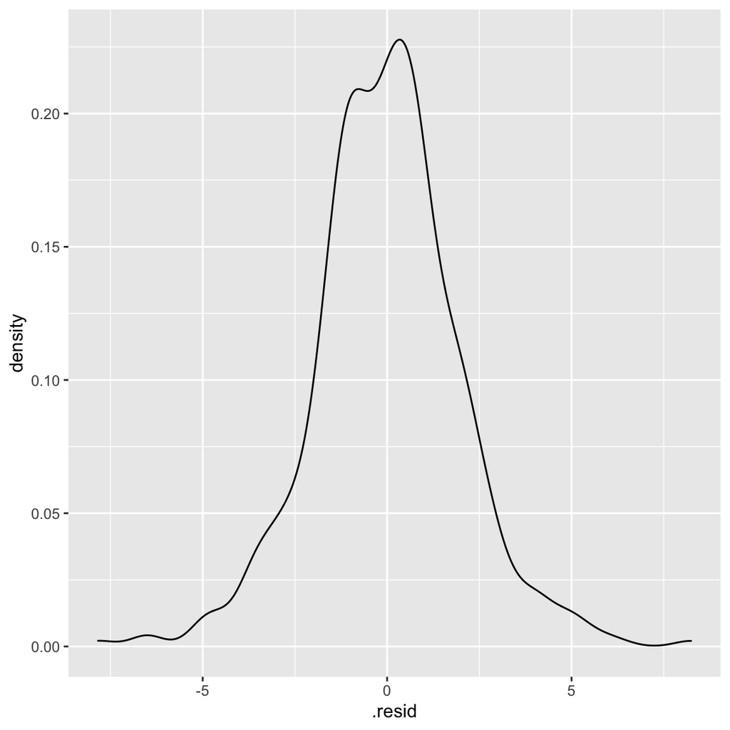

```r
m1.aug <- m1 %>% broom::augment()

m1.aug %>% ggplot(aes(.resid)) + geom_density()
```

This looks OK-ish, but a better way to check is to make a [qqplot](https://en.wikipedia.org/wiki/Q–Q_plot):

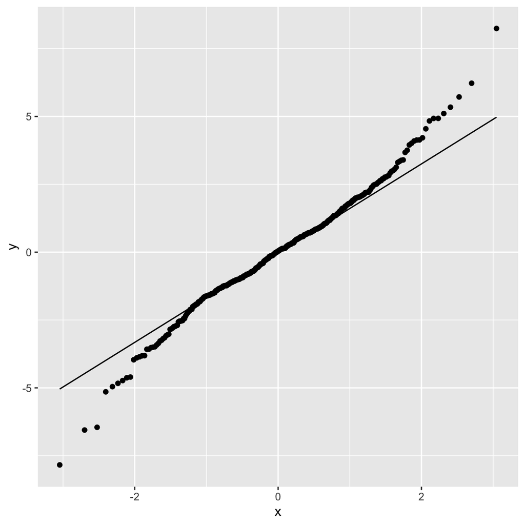

```r
m1.aug %>%
  ggplot(aes(sample=.resid)) + geom_qq_line() + geom_qq()
```

**Explanation**: If the residuals are normal we would see them falling along the line in this qqplot. That they deviate a little bit from the line suggests some non-normality.

If we re-fit the model with random slopes, let’s see if they improve:

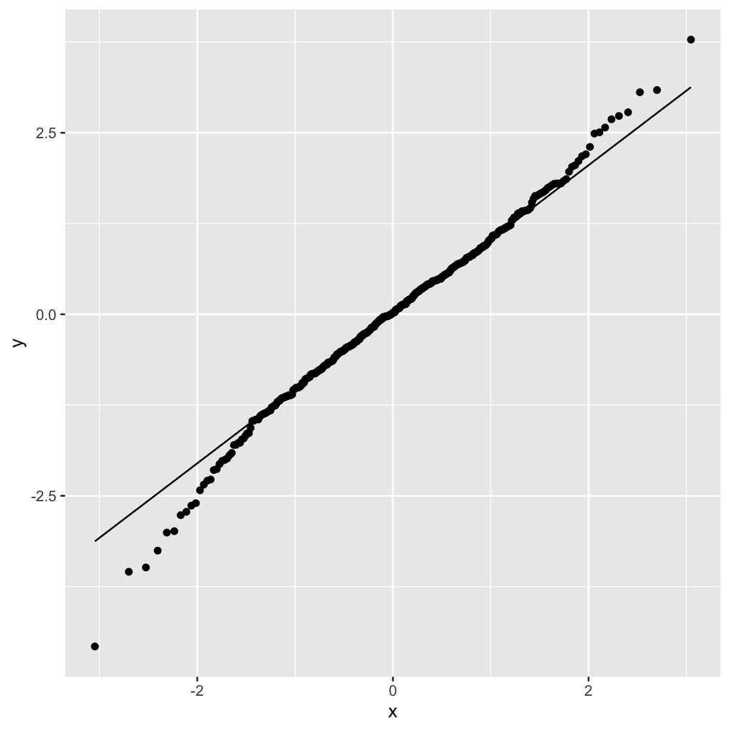

```r
m2 <- lmer(weight ~ week + (week|id), data=pigs)
m2 %>%
  broom::augment() %>%
  ggplot(aes(sample=.resid)) + geom_qq_line() + geom_qq()
```

That’s slightly better, as we can see if we plot both together:

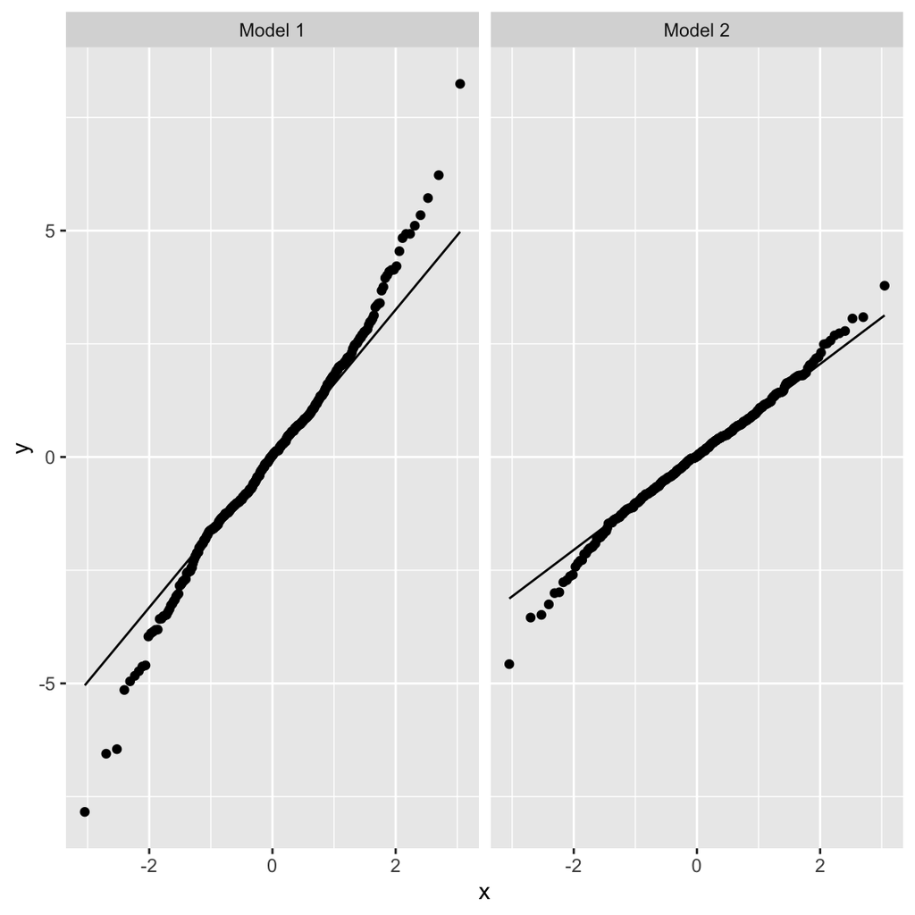

```r
bind_rows(m1 %>% broom::augment() %>% mutate(model=1), m2 %>% broom::augment() %>% mutate(model=2)) %>%
  ggplot(aes(sample=.resid)) + geom_qq_line() + geom_qq() + facet_wrap(~paste("Model", model))
```

Use a qqplot to check the residuals for one of the other plots you made.

## Checking heteroscedasticity

The quickest way to check heteroscedasticity is to simply call `plot` on a lmer model:

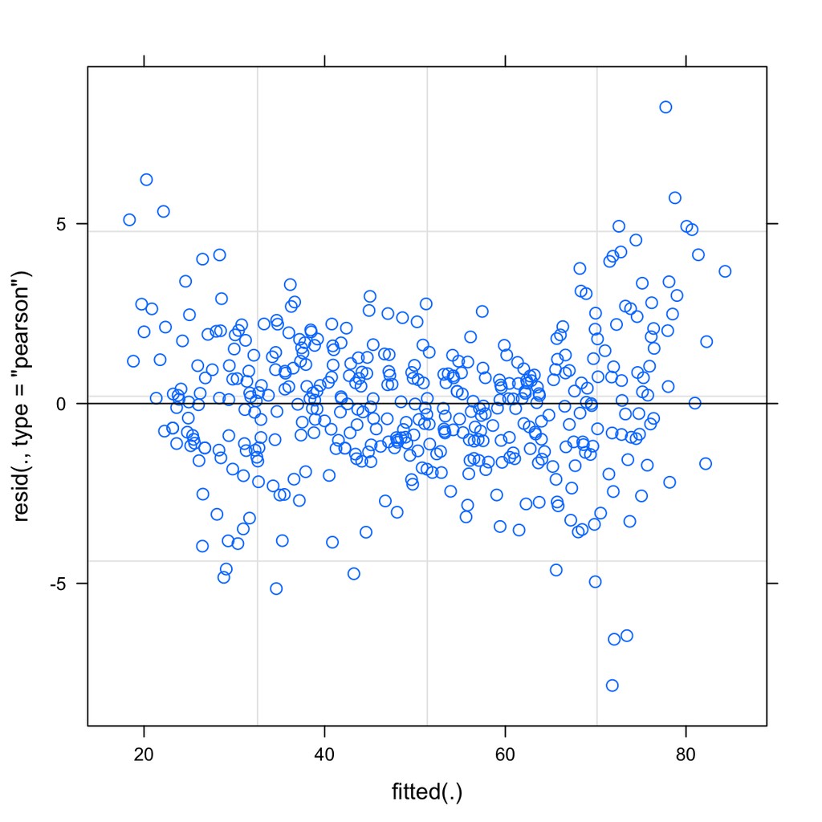

```r
plot(m1)
```

In this case we can see a tendency for larger positive residuals at extreme values of the fitted weight (it’s a bit like a smile). This suggests that our model can be improved.

In contrast, the plot for model 2 shows much less of this tendency.

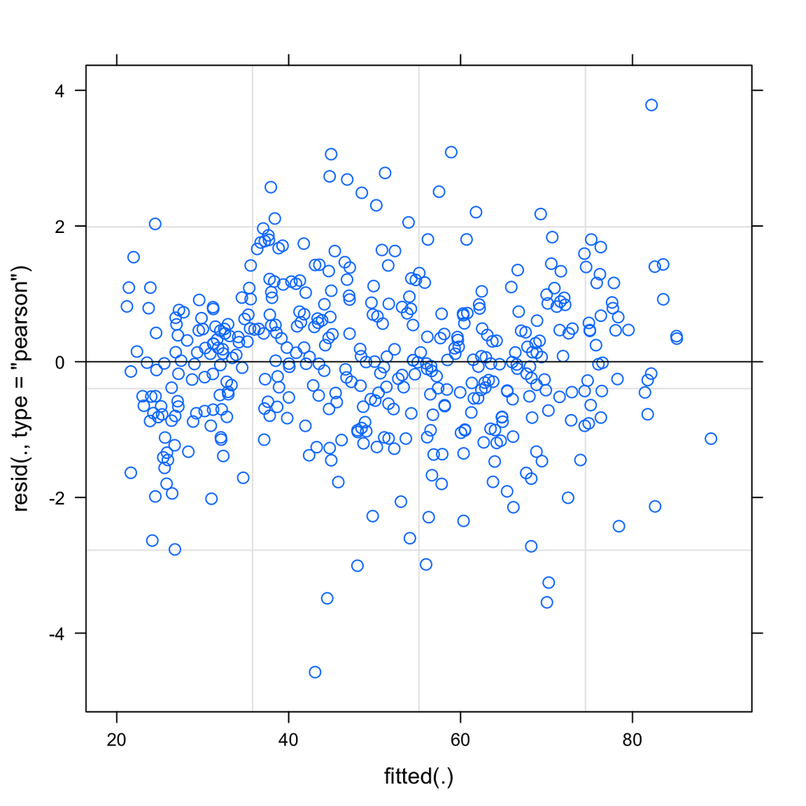

```r
plot(m2)
```

You can make this plot for yourself using ggplot if you like, too:

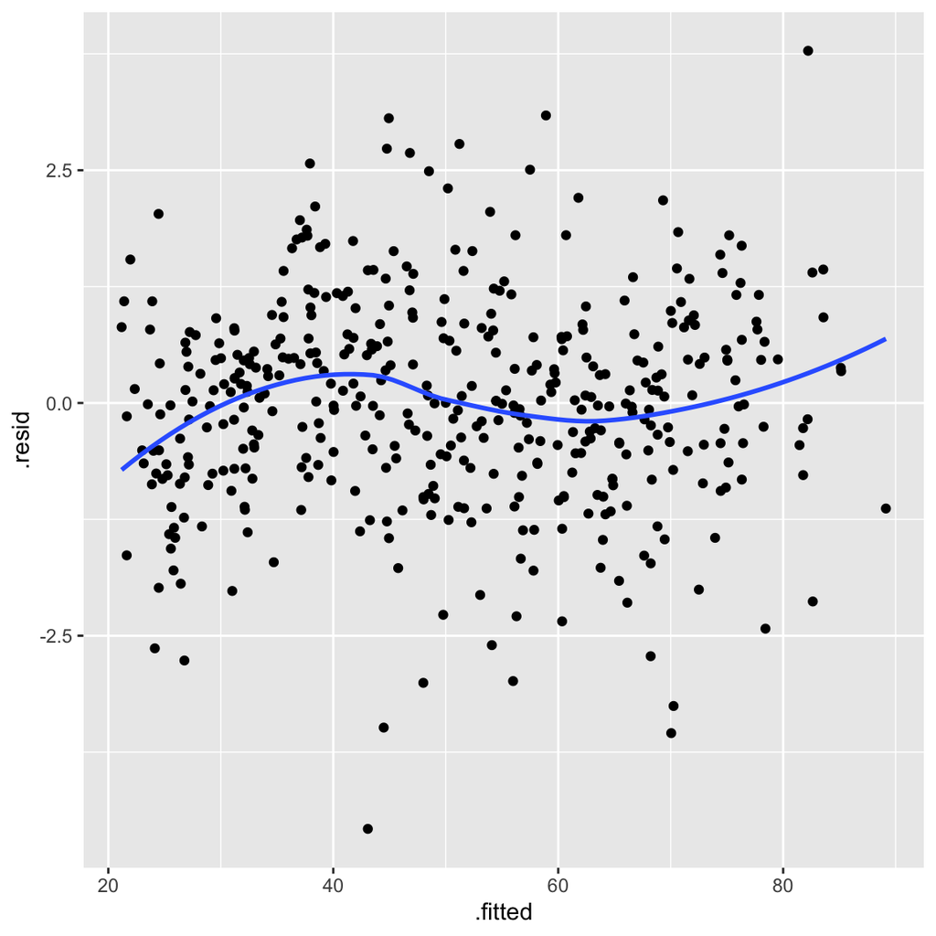

```r
m2 %>%
  broom::augment() %>%
  ggplot(aes(.fitted, .resid)) +
  geom_point() +
  geom_smooth(se=F)
```

## Is my plot “OK”?

The plots for m2 above look fine to me ;-). In general there’s no single answer, and as long as the plots look ‘OK’ it’s probably fine. Checking residuals plots is most useful in revealing gross violations of the model assumptions, and these will be obvious in the plots.

## More information/guidance

This page: https://www.ssc.wisc.edu/sscc/pubs/MM/MM_DiagInfer.html has much more info on diagnostics from mixed models.

In general, my advice would be to avoid formal statistical tests of residuals, but to spend some time checking plots for residual-normality and heteroscedasticity and use them heuristically to ensure you are fitting a suitable model. These probably have the biggest impact on inferences/testing you might want to do on these models, and are low hanging fruit.

## Checking random intercepts and slopes

We also assume that the distribution of random slopes and intercepts are normal.

We have to check these a slightly different way: we can get the between-cluster residuals by looking at the output of `ranef(model)`:

```r
ranef(m2) %>% as_tibble() %>% arrange(grp) %>% head()
```

```
# A tibble: 6 x 5
  grpvar term        grp   condval condsd
  <chr>  <fct>       <fct>   <dbl>  <dbl>
1 id     (Intercept) 26    -4.07    0.850
2 id     week        26    -0.313   0.152
3 id     (Intercept) 16    -3.84    0.850
4 id     week        16    -0.0823  0.152
5 id     (Intercept) 25    -3.72    0.850
6 id     week        25    -0.440   0.152
```

**Explanation**: In this table, `condval` is the residual for the cluster indexed by `grp`. The `term` column says whether it’s for the intercept or the slope.

We can plot these data like any other:

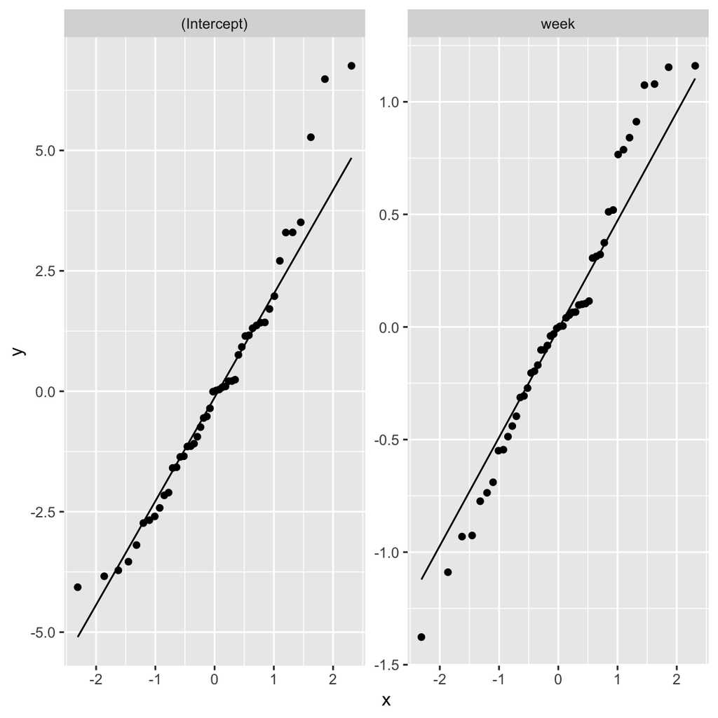

```r
ranef(m2) %>% as_tibble() %>%
  ggplot(aes(sample=condval)) +
    geom_qq_line() +
    geom_qq() +
    facet_wrap(~term, scales="free")
```

In both cases these look ‘OK’. It’s out of scope for this module to do anything about deviations from normality here, but:

- Random effects residuals might often look less normal simply because there are fewer data points, and so it’s harder to tell
- Deviations from normality probably mean you need to look again at the model you are running

**Don’t interpret or use *p* values from a model which had large deviations from normality in residuals or random effects.**

# Centering predictors (in regression)

In linear regression:

- coefficients in the model output are the **change in the outcome for a one unit change in the predictors, assuming all other predictors in the model are zero**.
- the intercept is the **expected value when all predictors are zero**

This is important because it affects how we interpret the parameters. When we include multiple predictors it can be hard to read the table of model parameters because we need to add together multiple parameters to make a prediction.

```r
lm(mpg~wt*am, data=mtcars)
```

```
Call:
lm(formula = mpg ~ wt * am, data = mtcars)

Coefficients:
(Intercept)           wt           am        wt:am
     31.416       -3.786       14.878       -5.298
```

Because weight in this sample ranges from 1.513 to 5.424, with mean = 3.21725. So, the intercept would not be an estimate for any car in the sample, because none of them actually had zero weight.

## Changing the scale/location of predictors

It’s surprising to some people that changing the scale and/or location of predictors in multiple regression doesn’t affect the way the model is fitted. Only the **interpretation** of the coefficients changes. The predictions the model makes would not change.

For example it would be fine to:

- subtract 10 or 100 or 1000 from every value of of a predictor
- multiply every value of a predictor by 10, or divide by 100

In both cases, the slope and the intercept coefficients would change, but the model $R^2$ and the predictions it makes would be the same (bar small differences caused by rounding errors).

If you find this surprising or not-intuitive try it for yourself. Run a `lm` model using the `mtcars` data with `mpg` as the outcome and `wt` as the predictor.

- Use mutate to multiply, divide or add a constant to the `wt` values in the data.
- Run different models with these different versions of the predictor
- Check your $R^2$ values are the same
- Check the predictions are the same
- Notice what changes have taken place to the coefficients.

This property — that the model is invariant to the scaling of predictors — is useful. We can **rescale predictors to make models easier to interpret**.

For example, if we *mean-centred* `wt` in our model `mpg ~ wt` then then we could interpret the intercept as the prediction when `wt` was at the average value in the sample. By mean-centrer, we mean “`wt`, minus the average of `wt` in the sample”.

This is what it looks like:

```r
mtcars.c <- mtcars %>% mutate(wt = wt - mean(wt))
lm(mpg ~ wt, data=mtcars.c)
```

```
Call:
lm(formula = mpg ~ wt, data = mtcars.c)

Coefficients:
(Intercept)           wt
     20.091       -5.344
```

**Explanation**: By centring the `wt` predictor the other coefficients, including the intercept changed. The intercept is the expectation when all predictors are zero. After centring, zero is the average of this variable in the sample, so the intercept is the expectation for the average.

# The `sleepstudy` data

The `sleepstudy` dataset we use here is included in the lmerTest package, so to access it you just need to load that:

```r
library(lmerTest)
```

The data show the increases in reaction times over the course of a 10 days experiment in which participants suffered sleep deprivation.

- Is there substantial variation between subjects in reaction times on average?
- Is there substantial variation in the effect of sleep deprivation on individuals?

There’s certainly variation in the slopes between individuals; the effect of sleep deprivation does seem to differ markedly between individuals.

However, deciding whether there is variation between people in average RTs is less clear-cut. We need to decide *on which day* we want to compare the variation.

For example, at day 0 there doesn’t seem to be much variation. But by day 5 there is, and by day 10 there is a lot.

As we’ll see, to estimate this variation from a model we need to be careful about how we include our covariates (e.g. days in this case).

# Centering in mixed models

In multiple regression centring predictors can be a convenience, but doesn’t affect the model fit[^1]. We can always do arithmetic on our coefficients to convert from one configuration to the another when making predictions.

*This is not true for mixed models*. How we include/encode predictors **changes the estimates of variance parameters**.

To see why, consider the sleepstudy plot again:

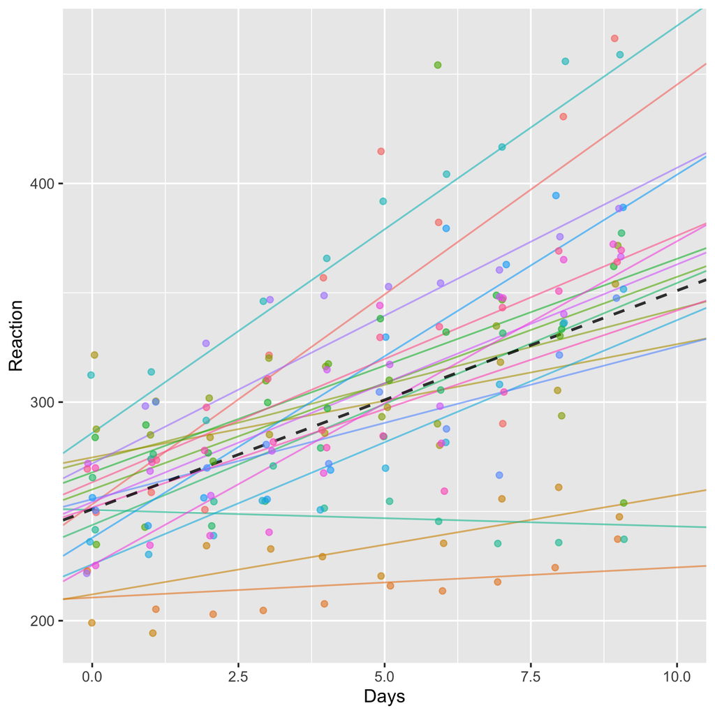

[output not shown]

[output not shown]

**BUT this small change is important** because our parameters are estimates when all the *other* predictors = zero.

Let’s estimate two models, one with Days as-is, and one with it centred:

```r
sleepstudy.c = sleepstudy %>%
  mutate(Days.c = Days - mean(Days))
```

```r
(sleep.m1 <- lmer(Reaction ~ Days + (Days | Subject), data=sleepstudy.c))
```

```
Linear mixed model fit by REML ['lmerModLmerTest']
Formula: Reaction ~ Days + (Days | Subject)
   Data: sleepstudy.c
REML criterion at convergence: 1743.628
Random effects:
 Groups   Name        Std.Dev. Corr
 Subject  (Intercept) 24.741
          Days         5.922   0.07
 Residual             25.592
Number of obs: 180, groups:  Subject, 18
Fixed Effects:
(Intercept)         Days
     251.41        10.47
```

```r
(sleep.m1.c <- lmer(Reaction ~ Days.c + (Days.c | Subject), data=sleepstudy.c))
```

```
Linear mixed model fit by REML ['lmerModLmerTest']
Formula: Reaction ~ Days.c + (Days.c | Subject)
   Data: sleepstudy.c
REML criterion at convergence: 1743.628
Random effects:
 Groups   Name        Std.Dev. Corr
 Subject  (Intercept) 37.532
          Days.c       5.922   0.75
 Residual             25.592
Number of obs: 180, groups:  Subject, 18
Fixed Effects:
(Intercept)       Days.c
     298.51        10.47
```

We should notice a few things here:

- Both of the coefficients for Days (`Days` and `Days.c`) are the same. This is because we simply subtracted 4.5 from all the `Days` and so the slope does not change
- The `intercept` values DOES change though. In the first model it is the expected value for participants on Day Zero. In the second model it’s the expected value on day 4.5 (the average).

However what we want focus on now is that:

- The variance parameters have also changed. The between-participant variance is much higher in the second model than the first.

If we compare the two plots we can see why:

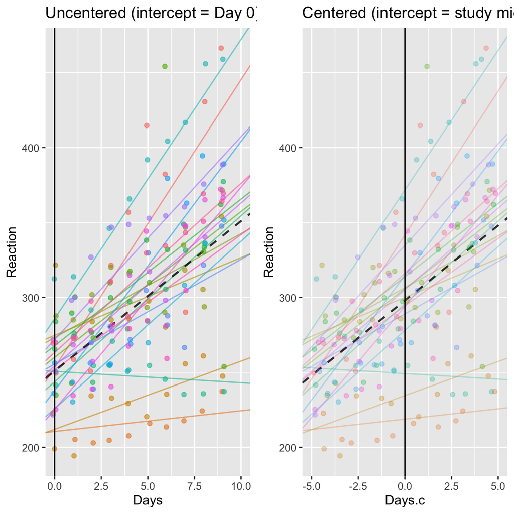

```r
ggpubr::ggarrange(sleeprandom+ggtitle("Uncentered (intercept = Day 0)")+geom_vline(xintercept=0),
                  sleeprandom2+ggtitle("Centered (intercept = study midpoint)")+geom_vline(xintercept=0),
                  nrow=1, ncol=2)
```

Remember that the between-subjects variance is estimated when all other predictors = zero. So in the first model, we are estimating the between-subject variance on the first day of the study — before anyone is sleep deprived. In the second plot we are estimating it after 4.5 days — midway through the study. At this point the variation between participants has increased — in part because the effect of sleep deprivation varies between individuals.

We could even supplement this with a third model, where we subtract 9 from `Days` and so `Days=0` becomes the end of the study:

```r
sleepstudy.c = sleepstudy %>%
  mutate(Days.c = Days - mean(Days), Days.sub9 = Days - 9)
```

```r
(sleep.m3 <- lmer(Reaction ~ Days.sub9 + (Days.sub9 | Subject), data=sleepstudy.c))
```

```
Linear mixed model fit by REML ['lmerModLmerTest']
Formula: Reaction ~ Days.sub9 + (Days.sub9 | Subject)
   Data: sleepstudy.c
REML criterion at convergence: 1743.628
Random effects:
 Groups   Name        Std.Dev. Corr
 Subject  (Intercept) 60.214
          Days.sub9    5.922   0.91
 Residual             25.592
Number of obs: 180, groups:  Subject, 18
Fixed Effects:
(Intercept)    Days.sub9
     345.61        10.47
```

Now we can see the between-subject variance has gone up even more (SD=60).

## How can we interpret this?

This plot simplifies things and shows the difference between models with centred and uncentred predictors, and when the predictor is centred at the endpoint of the study. The vertical dashed lines show where the variance for the random intercept would be taken from in each case:

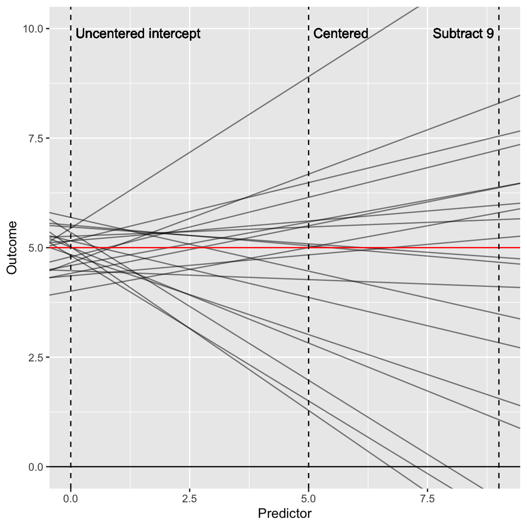

## What’s the right thing to do?

It depends on what your question is!

In the `sleepstudy` example we might argue that the first (uncentred) model makes more sense because there is a definite start to the experiment: At Day 0 we have people in their ‘natural’ state, before we deprive them of sleep. So in this model the `(Intercept)` term describes the variation between people in the normal state.

However if we wanted to describe the between-subject variance AFTER sleep deprivation then models 2 or 3 would make more sense.

**If you’re not sure, however, it’s probably safer to centre predictors in mixed models.**

In particular, variables like age or ‘year’ are worth centring because otherwise our model estimates variances at `year=0`, and you are very unlikely to have data on that, or be interested in the variance estimates for 2000 years ago!

Likewise, centring gender and other categorical predictors can make sense because otherwise the variance estimates will be for the group that is coded zero. Sometimes this wont matter, but often it will.

Return to the piglets example from sessions 1 and 2.

- Refit the model with centred predictors
- Calculate the variance partition by differences between piglets using centred and uncentred models. What differences do you spot?
- Which parameterisation makes most sense in this case? Are we more interested in variation between pigs at the start or the middle of the study?

# Politeness

Winter & Grawunder, 2012 describe a study of the pitch (frequency) of individuals’ speech when they recorded different phrases (scenarios). The scenarios differed in whether they required ‘politeness’ or were more informal in nature. The data are available online and can be read from the URL:

```r
# A reduced version of this dataset is also described and analysed in a mixed-models tutorial here: http://www.bodowinter.com/uploads/1/2/9/3/129362560/bw_lme_tutorial2.pdf.
politeness <-  read_csv("https://raw.githubusercontent.com/opetchey/BIO144/master/3_datasets/politeness_data.csv")
```

1. Make a plot showing how average levels of frequency differs *between individuals*.

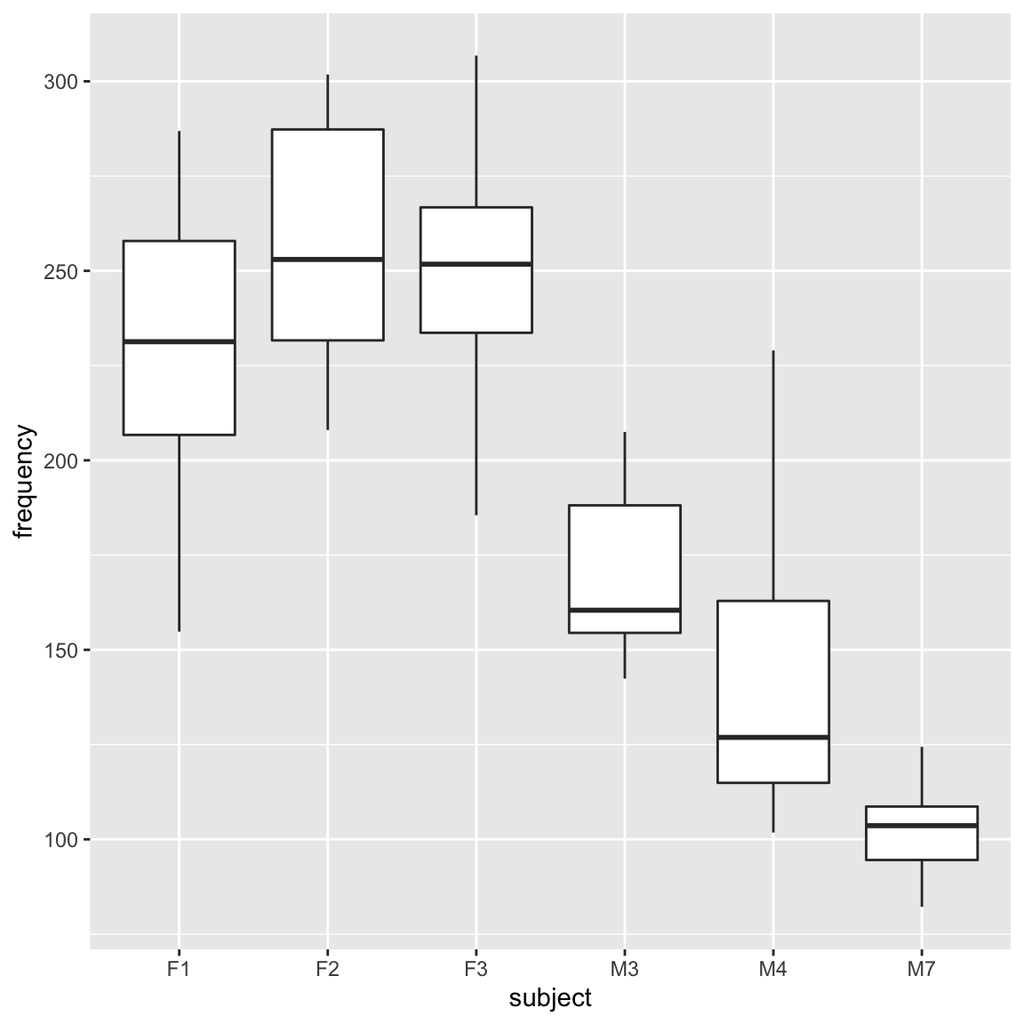

```r
politeness %>%
  ggplot(aes(subject, frequency)) + geom_boxplot()
```

2. Make a plot showing how frequency differs *between scenarios*

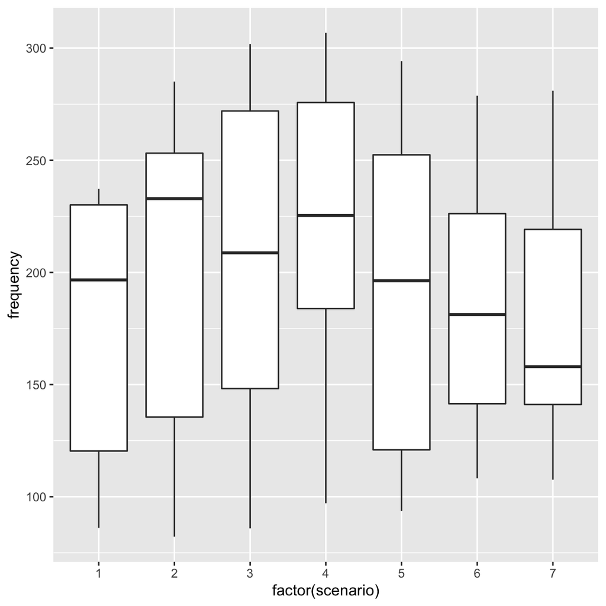

```r
politeness %>%
  ggplot(aes(factor(scenario), frequency)) + geom_boxplot()
```

3. Based on the plots, which do you think accounts for more variation in frequency: `subject` or `scenario`?

It looks like subjects vary more in frequency than do scenarios, but there appears to be variation attributable to both variables.

4. Fit a random intercepts model to the data, allowing for variation between subjects. Include fixed effects for `attitude` and `gender`:

```r
(polite.ri.subject <- lmer(frequency ~ attitude + gender + (1|subject), data=politeness))
```

```
Linear mixed model fit by REML ['lmerModLmerTest']
Formula: frequency ~ attitude + gender + (1 | subject)
   Data: politeness
REML criterion at convergence: 786.7439
Random effects:
 Groups   Name        Std.Dev.
 subject  (Intercept) 24.57
 Residual             29.17
Number of obs: 83, groups:  subject, 6
Fixed Effects:
(Intercept)  attitudepol      genderM
     256.69       -19.41      -108.20
```

You might then also want to look at the regression coefficients, Anova table, and tests of random effects:

```r
# regression coefficients
polite.ri.subject %>% summary %>% coef() %>% pander(caption="Model coefficients")
```

Model coefficients

|  | Estimate | Std. Error | df | t value | Pr(>\|t\|) |
| --- | --- | --- | --- | --- | --- |
| **(Intercept)** | 256.7 | 15.23 | 4.378 | 16.86 | 3.78e-05 |
| **attitudepol** | -19.41 | 6.407 | 76.02 | -3.03 | 0.003345 |
| **genderM** | -108.2 | 21.06 | 4.009 | -5.137 | 0.006766 |

```r
# anova-table
anova(polite.ri.subject) %>% pander(caption="Anova table")
```

Anova table

|  | Sum Sq | Mean Sq | NumDF | DenDF | F value | Pr(>F) |
| --- | --- | --- | --- | --- | --- | --- |
| **attitude** | 7810 | 7810 | 1 | 76.02 | 9.179 | 0.003345 |
| **gender** | 22457 | 22457 | 1 | 4.009 | 26.39 | 0.006766 |

```r
# tests of random effects
ranova(polite.ri.subject) %>% pander(caption="Test of random intercepts")
```

Test of random intercepts

|  | npar | logLik | AIC | LRT | Df | Pr(>Chisq) |
| --- | --- | --- | --- | --- | --- | --- |
|  | 5 | -393.4 | 796.7 | NA | NA | NA |
| **(1 \| subject)** | 4 | -404.7 | 817.4 | 22.68 | 1 | 1.909e-06 |

4. Fit a second random intercepts model, allowing for variation in both subjects and between the different scenarios.

```r
polite.ri.both <- lmer(frequency ~ attitude + gender +
                         (1|subject) + (1|scenario), data=politeness)

# test of random effect
ranova(polite.ri.both)
```

```
ANOVA-like table for random-effects: Single term deletions

Model:
frequency ~ attitude + gender + (1 | subject) + (1 | scenario)
               npar  logLik    AIC    LRT Df Pr(>Chisq)
<none>            6 -387.73 787.45
(1 | subject)     5 -402.50 815.00 29.546  1  5.461e-08 ***
(1 | scenario)    5 -393.37 796.74 11.289  1  0.0007796 ***
---
Signif. codes:  0 '***' 0.001 '**' 0.01 '*' 0.05 '.' 0.1 ' ' 1
```

5. How much variance was attributable to subjects or scenarios, compared with the total variance?

Remember to convert the `VarCorr` output to a dataframe to see the variance (rather than standard deviations) in the `vcov` column. You can then use `mutate` or `transmute` to calculate the within/between ratio (the ICC).

```r
polite.ri.both %>% VarCorr() %>% as_tibble() %>%
  transmute(
    Term=grp,
    `% variation`=round(vcov / sum(vcov) * 100, 1)
  ) %>%
  pander()
```

| Term | % variation |
| --- | --- |
| scenario | 14.8 |
| subject | 41.6 |
| Residual | 43.6 |

6. Add random slopes to the model above. Allow the effect of `attitude` (whether the scenario was polite or informal) to differ between the scenarios sampled in this study:

```r
frequency ~ attitude + gender + (1|subject) + (attitude|scenario)
```

```
frequency ~ attitude + gender + (1 | subject) + (attitude | scenario)
```

7. Use `ranova` to test whether adding random slopes improved the model.

First run the model:

```r
polite.rslopes <- lmer(frequency ~ attitude + gender + (1|subject) +
                         (attitude|scenario), data=politeness)
```

And then use `ranova`:

```r
ranova(polite.rslopes)
```

```
ANOVA-like table for random-effects: Single term deletions

Model:
frequency ~ attitude + gender + (1 | subject) + (attitude | scenario)
                                  npar  logLik    AIC     LRT Df Pr(>Chisq)
<none>                               8 -387.55 791.10
(1 | subject)                        7 -402.46 818.92 29.8223  1  4.735e-08 ***
attitude in (attitude | scenario)    6 -387.73 787.45  0.3523  2     0.8385
---
Signif. codes:  0 '***' 0.001 '**' 0.01 '*' 0.05 '.' 0.1 ' ' 1
```

The `Pr(>Chisq)` value for the attitude random slope is not statistically-significant.

7. If a random slopes model is not ‘significantly’ better than a similar model which does not include the random slope term, is there any reason why we might still prefer it, and use the ‘full’ model to base our inference on?

Yes - simulation studies, including Barr et al, 2013 suggest that a ‘maximal’ model is likely to be more conservative than a model which excludes non-significant random effects terms.

8. How might mixed models make the problem of ‘researcher degrees of freedom’ worse? What effect might this have? How can it be avoided?

Mixed models provide many more possible ‘ways to do it’. In addition to different fixed-effects specifications we can now also have many different random effects specifications. This increases degrees of freedom in the analysis, and makes it even more important to pre-specify analyses.

# Model complexity

Although Barr et al. (2013) exhort researchers to ‘keep it maximal’, and include as many random effects in the model as implied by the design, this isn’t always possible.

Mixed models with many random effects can be difficult to fit. If models become too complex, or we don’t have enough data to estimate all the parameters, you will see error messages about ‘singular fits’ and ‘non-convergence’.

These errors sound scary, and should actually be taken seriously:

- Non-converged models, or models with fit errors should NOT be interpreted or reported.
- Results from them are quite likely to be unstable/incorrect.
- The easiest/most immediate way to get rid of the errors is to simplify the model

## Simplifying a random slopes model

Let’s take one of the examples from above:

```r
(sleep.rs <- lmer(Reaction ~ Days + (Days|Subject), data=ss))
```

```
Linear mixed model fit by REML ['lmerModLmerTest']
Formula: Reaction ~ Days + (Days | Subject)
   Data: ss
REML criterion at convergence: 1743.628
Random effects:
 Groups   Name        Std.Dev. Corr
 Subject  (Intercept) 24.741
          Days         5.922   0.07
 Residual             25.592
Number of obs: 180, groups:  Subject, 18
Fixed Effects:
(Intercept)         Days
     251.41        10.47
```

This model contains 3 random effects parameters which have to be estimated from the data, plus the residual variance. We can see this using the `VarCorr` function:

```r
sleep.rs %>% VarCorr
```

```
 Groups   Name        Std.Dev. Corr
 Subject  (Intercept) 24.7407
          Days         5.9221  0.066
 Residual             25.5918
```

The coefficients which need to be estimated are:

- Random intercept term for Subject
- Random slope for Days within Subject
- The covariance of intercept and slope within Subject

Often, we will not have enough data to properly estimate all these parameters. Where this is the case, it’s often best to simplify the model by excluding parameters.

In this instance, the parameter we want to eliminate is the covariance of intercept and slope.

We can do this by changing the random effect specification from `(variable|grouping)` to say: `(1 | grouping) + (0 + variable | grouping)`

Explanation: In the second formula we ask for the random intercept and random slope separately. In the part which says `0+variable` we are saying ‘add the random slope but not a random intercept’. Because the intercept and slope are specified separately, R doesn’t add the covariance between them.

Use the sleepstudy data. Adjust the model `Reaction ~ Days + (Days|Subject)` to exclude the covariance of random intercepts and slopes.

```r
lmer(Reaction ~ Days + (1|Subject) + (0+Days|Subject), data=ss)
```

```
Linear mixed model fit by REML ['lmerModLmerTest']
Formula: Reaction ~ Days + (1 | Subject) + (0 + Days | Subject)
   Data: ss
REML criterion at convergence: 1743.669
Random effects:
 Groups    Name        Std.Dev.
 Subject   (Intercept) 25.051
 Subject.1 Days         5.988
 Residual              25.565
Number of obs: 180, groups:  Subject, 18
Fixed Effects:
(Intercept)         Days
     251.41        10.47
```

# Further reading

Meteyard summarises current good practice in running and reporting mixed models (Meteyard and Davies 2020).

Barr et al (2013) go into more detail on why mixed models are preferable to RM anova, and this paper will be a useful reference for future sessions too. See also Eager and Roy (2017) which points out some of the failings of mixed models as typically used.

# References

Barr, Dale J, Roger Levy, Christoph Scheepers, and Harry J Tily. 2013. “Random Effects Structure for Confirmatory Hypothesis Testing: Keep It Maximal.” *Journal of Memory and Language* 68 (3): 255–78.

Eager, Christopher, and Joseph Roy. 2017. “Mixed Effects Models Are Sometimes Terrible.” *arXiv Preprint arXiv:1701.04858*.

Meteyard, Lotte, and Robert AI Davies. 2020. “Best Practice Guidance for Linear Mixed-Effects Models in Psychological Science.” *Journal of Memory and Language* 112: 104092.

[^1]: This is mostly true. The only exception is when parameters are collinear (see PSYC753 materials); in this case numerical issues when fitting models can lead to small differences, but this is mostly not the case.